# ASSIGNMENT 5: FMST

### Make the necessary imports

```python
import numpy as np
import pandas as pd
import matplotlib.pyplot as plt
import seaborn as sns
from sklearn.model_selection import train_test_split, cross_val_score, KFold, GridSearchCV, RandomizedSearchCV
from sklearn.metrics import classification_report, confusion_matrix, accuracy_score
from sklearn.model_selection import cross_val_score
from sklearn.preprocessing import MinMaxScaler
from sklearn.preprocessing import PolynomialFeatures
from scipy.stats import zscore as z_score
from sklearn.linear_model import LinearRegression
from sklearn.linear_model import Ridge
from sklearn.linear_model import Lasso
from sklearn.tree import DecisionTreeRegressor
from sklearn.svm import SVR
from sklearn.pipeline import make_pipeline as make_new_pipeline, Pipeline
from sklearn.cluster import KMeans
from sklearn.impute import SimpleImputer
%matplotlib inline
```

### Read the data

```python
concrete = pd.read_csv("data\\concrete.csv")
```

### Append attribute descriptions and view the data head

```python
concrete.col_description = {
    "cement": "Cement is the hydraulic binder (hydraulic = hardening when combined with water) which is used to produce concrete. Cement paste (cement mixed with water) sets and hardens by hydration, both in air and under water. The main base materials, e.g. for Portland cement, are limestone, marl and clay, which are mixed in defined proportions. This raw mix is burned at about 1,450 °C to form clinker which is later ground to the well-known fineness of cement",
    "slag": "Slag is the glass-like by-product left over after a desired metal has been separated from its raw ore. Slag is usually a mixture of metal oxides and silicon dioxide",
    "ash": "Is a by product of coal burning plants. Fly ash can replace 15%-30% of the cement in the mix. Cement and fly ash together in the same mix make up the total cementious material",
    "water": "Water",
    "superplastic": "Superplasticizers (SP's), also known as high range water reducers, are additives used in making high strength concrete. Plasticizers are chemical compounds that enable the production of concrete with ca. 15% less water content. Superplasticizers allow reduction in water content by 30% or more",
    "coarseagg": "(Coarse)Concrete aggregates, consisting of sand and gravel, represent the grain skeleton of the concrete. All cavities within this skeleton have to be filled with binder paste as much as possible. Concrete aggregates sum up to approximately 80% of the concrete weight and 70% of the concrete volume. Optimum use of the aggregate size and quality improves the concrete quality",
    "fineagg": "(FINE)Concrete aggregates, consisting of sand and gravel, represent the grain skeleton of the concrete. All cavities within this skeleton have to be filled with binder paste as much as possible. Concrete aggregates sum up to approximately 80% of the concrete weight and 70% of the concrete volume. Optimum use of the aggregate size and quality improves the concrete quality",
    "age": "number of days the mixture settles, concrete gets stronger the longer it is allowed to hydrate",
    "strength": "Concrete compressive strength measured in MPa"
}
with pd.HDFStore("concrete.h5") as concrete_store:
    concrete_store.put("df", concrete)
    concrete_store.get_storer("df").attrs.col_description = concrete.col_description
with pd.HDFStore("concrete.h5") as concrete_store:
    concrete = concrete_store.get("df")
    concrete.col_description = concrete_store.get_storer("df").attrs.col_description
print(concrete.col_description["cement"]) ## testing if the descriptions are recovered
concrete.head()
```

```
Cement is the hydraulic binder (hydraulic = hardening when combined with water) which is used to produce concrete. Cement paste (cement mixed with water) sets and hardens by hydration, both in air and under water. The main base materials, e.g. for Portland cement, are limestone, marl and clay, which…
```

|  | cement | slag | ash | water | superplastic | coarseagg | fineagg | age | strength |
| --- | --- | --- | --- | --- | --- | --- | --- | --- | --- |
| 0 | 141.3 | 212.0 | 0.0 | 203.5 | 0.0 | 971.8 | 748.5 | 28 | 29.89 |
| 1 | 168.9 | 42.2 | 124.3 | 158.3 | 10.8 | 1080.8 | 796.2 | 14 | 23.51 |
| 2 | 250.0 | 0.0 | 95.7 | 187.4 | 5.5 | 956.9 | 861.2 | 28 | 29.22 |
| 3 | 266.0 | 114.0 | 0.0 | 228.0 | 0.0 | 932.0 | 670.0 | 28 | 45.85 |
| 4 | 154.8 | 183.4 | 0.0 | 193.3 | 9.1 | 1047.4 | 696.7 | 28 | 18.29 |

### View column info

```python
concrete.info()
```

```
<class 'pandas.core.frame.DataFrame'>
Int64Index: 1030 entries, 0 to 1029
Data columns (total 9 columns):
cement          1030 non-null float64
slag            1030 non-null float64
ash             1030 non-null float64
water           1030 non-null float64
superplastic    1030 non-null float64
coarseagg       1030 non-null float64
fineagg         1030 non-null float64
age             1030 non-null int64
strength        1030 non-null float64
dtypes: float64(8), int64(1)
memory usage: 80.5 KB
```

### Observation

```
1. All columns are numeric
2. There are no null values
```

```python
print(concrete[np.isnan(concrete["cement"])]["cement"].count())
print(concrete[np.isnan(concrete["slag"])]["slag"].count())
print(concrete[np.isnan(concrete["ash"])]["ash"].count())
print(concrete[np.isnan(concrete["water"])]["water"].count())
print(concrete[np.isnan(concrete["superplastic"])]["superplastic"].count())
print(concrete[np.isnan(concrete["coarseagg"])]["coarseagg"].count())
print(concrete[np.isnan(concrete["fineagg"])]["fineagg"].count())
print(concrete[np.isnan(concrete["age"])]["age"].count())
```

```
0
0
0
0
0
0
0
0
```

### Observation

```
1. No NaNs in the dataset
```

```python
print(concrete[concrete["cement"] == 0]["cement"].count())
print(concrete[concrete["slag"] == 0]["slag"].count())
print(concrete[concrete["ash"] == 0]["ash"].count())
print(concrete[concrete["water"] == 0]["water"].count())
print(concrete[concrete["superplastic"] == 0]["superplastic"].count())
print(concrete[concrete["coarseagg"] == 0]["coarseagg"].count())
print(concrete[concrete["fineagg"] == 0]["fineagg"].count())
print(concrete[concrete["age"] == 0]["age"].count())
```

```
0
471
566
0
379
0
0
0
```

### Observation

```
1. Slag, Ash and SuperPlasticizer have a lot of Zero values
2. The volume of these entries suggests that this is acceptable, Also external research supports this theory.
```

```python
print(concrete[concrete["cement"] < 0]["cement"].count())
print(concrete[concrete["slag"] < 0]["slag"].count())
print(concrete[concrete["ash"] < 0]["ash"].count())
print(concrete[concrete["water"] < 0]["water"].count())
print(concrete[concrete["superplastic"] < 0]["superplastic"].count())
print(concrete[concrete["coarseagg"] < 0]["coarseagg"].count())
print(concrete[concrete["fineagg"] < 0]["fineagg"].count())
print(concrete[concrete["age"] < 0]["age"].count())
```

```
0
0
0
0
0
0
0
0
```

### Observation

```
1. There are no Negative Values in the set
```

## Q1 Univariate analysis

## Ans1

```
array([[<matplotlib.axes._subplots.AxesSubplot object at 0x0000027727EB6940>,
      dtype=object)
```

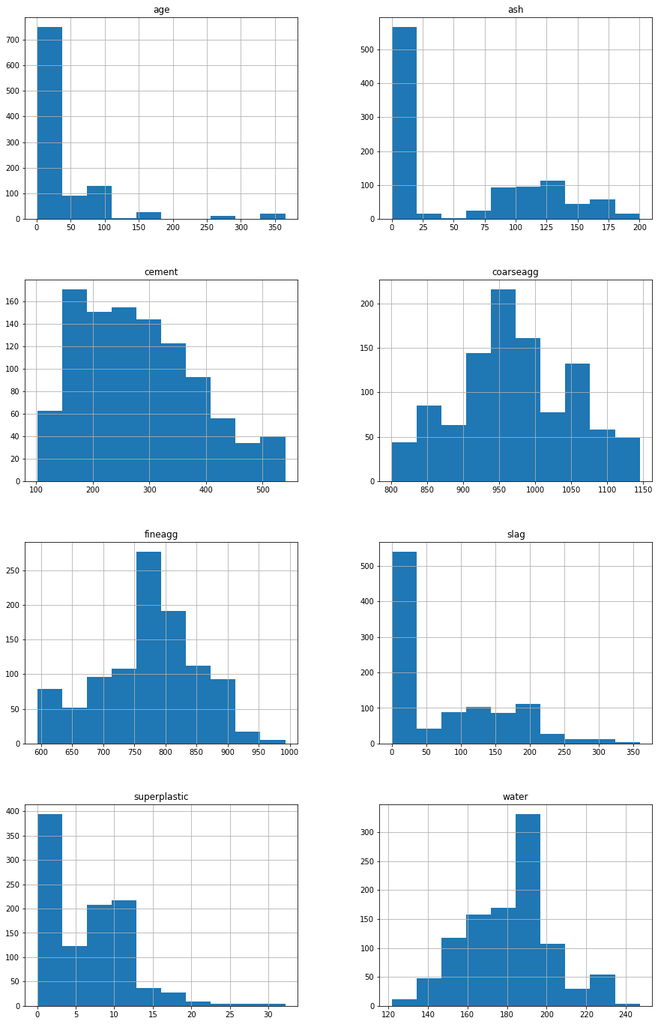

```python
concrete.drop("strength", axis = 1).hist(stacked = False, figsize = (15,50), layout = (8,2))
```

### Observation

[output not shown]

### Individual Variables KDE, BoxPlots, Quartiles and Zscores

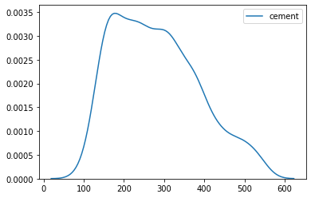

```python
sns.kdeplot(concrete["cement"])
```

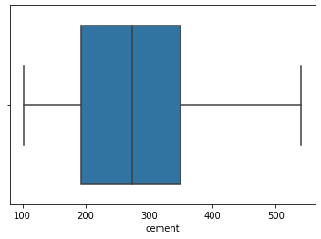

```python
sns.boxplot(concrete["cement"])
```

```python
np.percentile(concrete["cement"], [0,25,50,75,100])
```

```
array([102.   , 192.375, 272.9  , 350.   , 540.   ])
```

```python
z_cement = z_score(concrete["cement"])
print(np.max(z_cement))
print(np.min(z_cement))
```

```
2.4779148658211825
-1.715253449087601
```

### Observation

```
1. The Cement numbers seem to have a mild right tail, the median is 272.9
2. The range is acceptable at the 3 sigma level, z = (-1.71, 2.48)
```

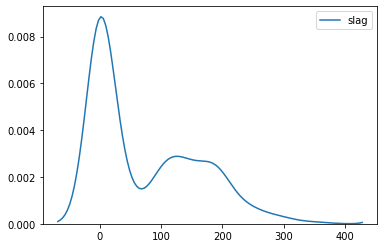

```python
sns.kdeplot(concrete["slag"])
```

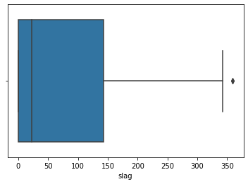

```python
sns.boxplot(concrete["slag"])
```

```python
np.percentile(concrete["slag"], [0,25,50,75,100])
```

```
array([  0.  ,   0.  ,  22.  , 142.95, 359.4 ])
```

```python
z_slag = z_score(concrete["slag"])
print(np.max(z_slag))
print(np.min(z_slag))
```

```
3.3106751190879606
-0.8568878904959009
```

### Observation

```
1. The slag distribution has a significant right tail, There seems to be two gaussians underneath, the median is 22
2. There seems to be some outliers z at the 3 sigma level = (-0.86, 3.31)
3. We will discover these outliers and treat them later
```

```python
concrete[z_slag>3]
```

|  | cement | slag | ash | water | superplastic | coarseagg | fineagg | age | strength |
| --- | --- | --- | --- | --- | --- | --- | --- | --- | --- |
| 21 | 228.0 | 342.1 | 0.0 | 185.7 | 0.0 | 955.8 | 674.3 | 7 | 21.92 |
| 564 | 228.0 | 342.1 | 0.0 | 185.7 | 0.0 | 955.8 | 674.3 | 28 | 39.70 |
| 918 | 239.6 | 359.4 | 0.0 | 185.7 | 0.0 | 941.6 | 664.3 | 28 | 39.44 |
| 990 | 239.6 | 359.4 | 0.0 | 185.7 | 0.0 | 941.6 | 664.3 | 7 | 25.42 |

### Observation

```
We only have four records in above z=3
```

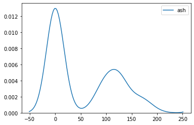

```python
sns.kdeplot(concrete["ash"])
```

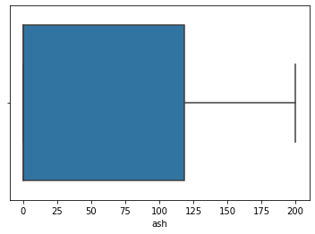

```python
sns.boxplot(concrete["ash"])
```

```python
np.percentile(concrete["ash"], [0,25,50,75,100])
```

```
array([  0. ,   0. ,   0. , 118.3, 200.1])
```

```python
z_ash = z_score(concrete["ash"])
print(np.max(z_ash))
print(np.min(z_ash))
```

```
2.2810838559426596
-0.847143931595683
```

### Observation

```
1. The ash distribution has a significant right tail and has two possible Gaussians, the median seems to be 0
2. There seems to be no outliers at the 3 sigma level, z = (-0.85, 2.28)
```

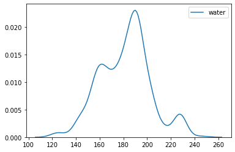

```python
sns.kdeplot(concrete["water"])
```

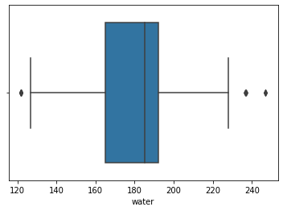

```python
sns.boxplot(concrete["water"])
```

```python
np.percentile(concrete["water"], [0,25,50,75,100])
```

```
array([121.8, 164.9, 185. , 192. , 247. ])
```

```python
z_water = z_score(concrete["water"])
print(np.max(z_water))
print(np.min(z_water))
```

```
3.065647419981685
-2.8002109165465834
```

### Observation

```
1. The water distribution seems to have a mild left tail, median is 185. There appears to be three potential Gaussians
2. The range has potential outliers at the 3 sigma level, z = (-2.8, 3.06)
3. We will discover the outliers and treat them later
```

```python
concrete[z_water>3]
```

|  | cement | slag | ash | water | superplastic | coarseagg | fineagg | age | strength |
| --- | --- | --- | --- | --- | --- | --- | --- | --- | --- |
| 66 | 237.0 | 92.0 | 71.0 | 247.0 | 6.0 | 853.0 | 695.0 | 28 | 28.63 |
| 263 | 236.9 | 91.7 | 71.5 | 246.9 | 6.0 | 852.9 | 695.4 | 28 | 28.63 |

### Observation

```
We have only two records which are outside the 3 sigma interval
```

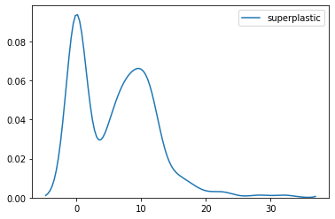

```python
sns.kdeplot(concrete["superplastic"])
```

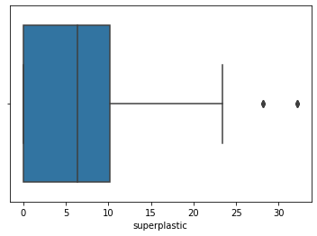

```python
sns.boxplot(concrete["superplastic"])
```

```python
np.percentile(concrete["superplastic"], [0,25,50,75,100])
```

```
array([ 0. ,  0. ,  6.4, 10.2, 32.2])
```

```python
z_sp = z_score(concrete["superplastic"])
print(np.max(z_sp))
print(np.min(z_sp))
```

```
4.353642219500018
-1.0391428148578055
```

### Observation

```
1. The distribution has a large right tail, median value is 6.4. The distribution again indicates 2 Gaussians
2. The range has potential outliers at the 3 sigma level, z = (-1.04, 4.35)
3. We will discover the outliers and treat them later
```

```python
concrete[z_sp>3]
```

|  | cement | slag | ash | water | superplastic | coarseagg | fineagg | age | strength |
| --- | --- | --- | --- | --- | --- | --- | --- | --- | --- |
| 44 | 531.3 | 0.0 | 0.0 | 141.8 | 28.2 | 852.1 | 893.7 | 91 | 59.2 |
| 156 | 531.3 | 0.0 | 0.0 | 141.8 | 28.2 | 852.1 | 893.7 | 28 | 56.4 |
| 232 | 469.0 | 117.2 | 0.0 | 137.8 | 32.2 | 852.1 | 840.5 | 56 | 69.3 |
| 292 | 469.0 | 117.2 | 0.0 | 137.8 | 32.2 | 852.1 | 840.5 | 91 | 70.7 |
| 538 | 531.3 | 0.0 | 0.0 | 141.8 | 28.2 | 852.1 | 893.7 | 7 | 46.9 |
| 744 | 469.0 | 117.2 | 0.0 | 137.8 | 32.2 | 852.1 | 840.5 | 7 | 54.9 |
| 816 | 469.0 | 117.2 | 0.0 | 137.8 | 32.2 | 852.1 | 840.5 | 28 | 66.9 |
| 838 | 531.3 | 0.0 | 0.0 | 141.8 | 28.2 | 852.1 | 893.7 | 56 | 58.8 |
| 955 | 469.0 | 117.2 | 0.0 | 137.8 | 32.2 | 852.1 | 840.5 | 3 | 40.2 |
| 1026 | 531.3 | 0.0 | 0.0 | 141.8 | 28.2 | 852.1 | 893.7 | 3 | 41.3 |

### Observation

```
1. Around 10 records are outside the 3 sigma range.
```

```python
concrete[z_sp>4]
```

|  | cement | slag | ash | water | superplastic | coarseagg | fineagg | age | strength |
| --- | --- | --- | --- | --- | --- | --- | --- | --- | --- |
| 232 | 469.0 | 117.2 | 0.0 | 137.8 | 32.2 | 852.1 | 840.5 | 56 | 69.3 |
| 292 | 469.0 | 117.2 | 0.0 | 137.8 | 32.2 | 852.1 | 840.5 | 91 | 70.7 |
| 744 | 469.0 | 117.2 | 0.0 | 137.8 | 32.2 | 852.1 | 840.5 | 7 | 54.9 |
| 816 | 469.0 | 117.2 | 0.0 | 137.8 | 32.2 | 852.1 | 840.5 | 28 | 66.9 |
| 955 | 469.0 | 117.2 | 0.0 | 137.8 | 32.2 | 852.1 | 840.5 | 3 | 40.2 |

### Observation

```
1. 5 records are outside the 4 sigma range
```

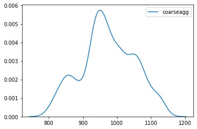

```python
sns.kdeplot(concrete["coarseagg"])
```

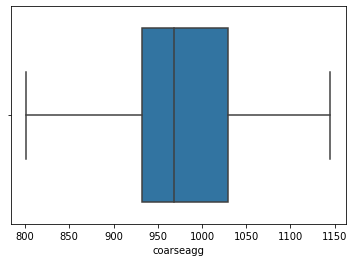

```python
sns.boxplot(concrete["coarseagg"])
```

```python
np.percentile(concrete["coarseagg"], [0,25,50,75,100])
```

```
array([ 801. ,  932. ,  968. , 1029.4, 1145. ])
```

```python
z_ca = z_score(concrete["coarseagg"])
print(np.max(z_ca))
print(np.min(z_ca))
```

```
2.2142239018379497
-2.2121376454076307
```

### Observation

```
1. The range is normal, the median value is around 968, The distribution indicates atleast 2 Gaussians
2. The range has no outliers at the 3 sigma level, z = (-2.21, 2.21)
```

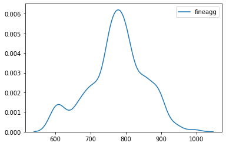

```python
sns.kdeplot(concrete["fineagg"])
```

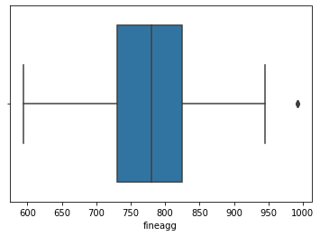

```python
sns.boxplot(concrete["fineagg"])
```

```python
np.percentile(concrete["fineagg"], [0,25,50,75,100])
```

```
array([594.  , 730.95, 779.5 , 824.  , 992.6 ])
```

```python
z_fa = z_score(concrete["fineagg"])
print(np.max(z_fa))
print(np.min(z_fa))
```

```
2.7330618447929567
-2.2409170881234535
```

### Observation

```
1. The range is normal, the median value is around 779.5, the distribution indicates two potential Gaussians
2. The range has no outliers at the 3 sigma level, z = (-2.24, 2.73)
```

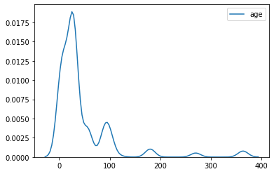

```python
sns.kdeplot(concrete["age"])
```

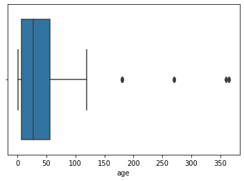

```python
sns.boxplot(concrete["age"])
```

```python
np.percentile(concrete["age"], [0,25,50,75,100])
```

```
array([  1.,   7.,  28.,  56., 365.])
```

```python
z_age = z_score(concrete["age"])
print(np.max(z_age))
print(np.min(z_age))
```

```
5.057676786792999
-0.7073594255895131
```

### Observation

```
1. The range is normal, the median value is around 28. This graph again suggests two potential Gaussians at least
2. The range has certain outliers at the 3 sigma level, z = (-0.71, 5.06)
3. We will have to investigate the outlier and treat them
```

```python
concrete[z_age>3.6]
```

|  | cement | slag | ash | water | superplastic | coarseagg | fineagg | age | strength |
| --- | --- | --- | --- | --- | --- | --- | --- | --- | --- |
| 64 | 332.5 | 142.5 | 0.0 | 228.0 | 0.0 | 932.0 | 594.0 | 365 | 41.05 |
| 133 | 236.0 | 0.0 | 0.0 | 193.0 | 0.0 | 968.0 | 885.0 | 365 | 25.08 |
| 157 | 198.6 | 132.4 | 0.0 | 192.0 | 0.0 | 978.4 | 825.5 | 360 | 44.30 |
| 159 | 304.0 | 76.0 | 0.0 | 228.0 | 0.0 | 932.0 | 670.0 | 365 | 55.26 |
| 198 | 266.0 | 114.0 | 0.0 | 228.0 | 0.0 | 932.0 | 670.0 | 365 | 52.91 |
| 323 | 139.6 | 209.4 | 0.0 | 192.0 | 0.0 | 1047.0 | 806.9 | 360 | 44.70 |
| 361 | 277.0 | 0.0 | 0.0 | 191.0 | 0.0 | 968.0 | 856.0 | 360 | 33.70 |
| 393 | 342.0 | 38.0 | 0.0 | 228.0 | 0.0 | 932.0 | 670.0 | 365 | 56.14 |
| 448 | 331.0 | 0.0 | 0.0 | 192.0 | 0.0 | 978.0 | 825.0 | 360 | 41.24 |
| 465 | 427.5 | 47.5 | 0.0 | 228.0 | 0.0 | 932.0 | 594.0 | 365 | 43.70 |
| 484 | 237.5 | 237.5 | 0.0 | 228.0 | 0.0 | 932.0 | 594.0 | 365 | 39.00 |
| 601 | 339.0 | 0.0 | 0.0 | 197.0 | 0.0 | 968.0 | 781.0 | 365 | 38.89 |
| 713 | 190.0 | 190.0 | 0.0 | 228.0 | 0.0 | 932.0 | 670.0 | 365 | 53.69 |
| 720 | 380.0 | 95.0 | 0.0 | 228.0 | 0.0 | 932.0 | 594.0 | 365 | 43.70 |
| 754 | 254.0 | 0.0 | 0.0 | 198.0 | 0.0 | 968.0 | 863.0 | 365 | 29.79 |
| 755 | 349.0 | 0.0 | 0.0 | 192.0 | 0.0 | 1047.0 | 806.0 | 360 | 42.13 |
| 901 | 475.0 | 0.0 | 0.0 | 228.0 | 0.0 | 932.0 | 594.0 | 365 | 41.93 |
| 919 | 310.0 | 0.0 | 0.0 | 192.0 | 0.0 | 970.0 | 850.0 | 360 | 38.11 |
| 957 | 307.0 | 0.0 | 0.0 | 193.0 | 0.0 | 968.0 | 812.0 | 365 | 36.15 |
| 995 | 380.0 | 0.0 | 0.0 | 228.0 | 0.0 | 932.0 | 670.0 | 365 | 52.52 |

### Observation

```
1. Total outliers outside z = 3.6 is 20
```

### TARGET VARIABLE

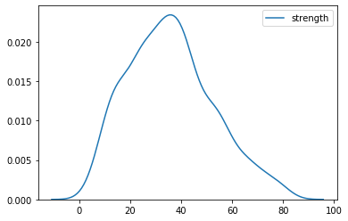

```python
sns.kdeplot(concrete["strength"])
```

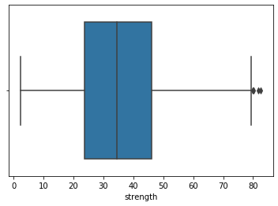

```python
sns.boxplot(concrete["strength"])
```

```python
np.percentile(concrete["strength"], [0,25,50,75,100])
```

```
array([ 2.33 , 23.71 , 34.445, 46.135, 82.6  ])
```

```python
z_strength = z_score(concrete["strength"])
print(np.max(z_strength))
print(np.min(z_strength))
```

```
2.801717231048534
-2.005551706709792
```

### Observation

```
1. The range is normal, the median value is around 34
2. The range has no outliers at the 3 sigma level, z = (-2.0, 2.8)
```

## Q2 MultiVariate Analysis

## Ans2

### Create a Pairplot

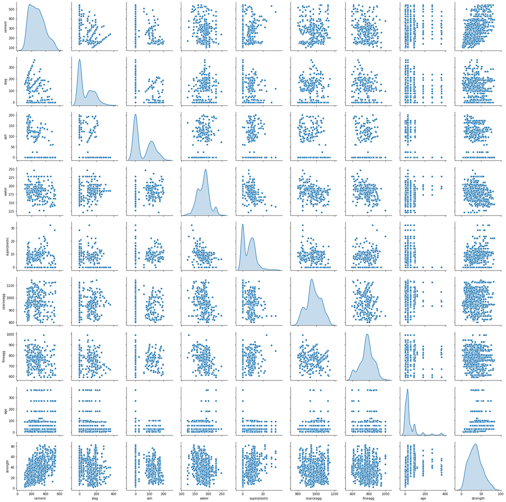

```python
sns.pairplot(concrete,diag_kind = "kde")
```

### Observation

```
1. Greater water -> Lower strength (weak trend/correlation)
2. Greater cement -> higher strength (weak trend/correlation)
3. No clearly observable trends for slag, coarse and fine agg (potentially droppable variables, we will evaluate in detail)
4. Greater age -> higher strength (only upto a number of days after which it seems to plateau)
5. Greater superplasticizer -> higher strength
6. Greater ash -> lower strength (makes it easier to work)
7. Total potential Gaussians = 3 * 3 (we see atleast 2 elements with distributions that could potentially have 3 mixed distributions)
```

### Create a Heatmap

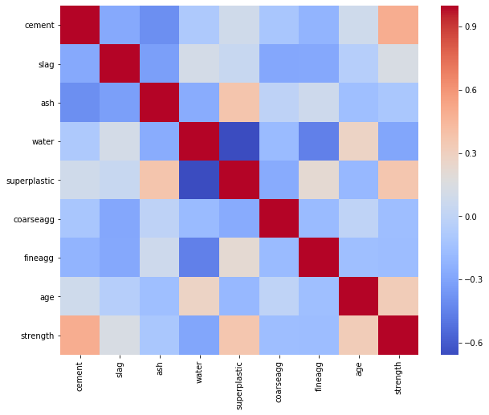

```python
cmat = concrete.corr()
plt.figure(figsize = (10,8))
sns.heatmap(cmat, cmap="coolwarm")
```

### Observations

```
1. Age, Cement and Superplastic: moderate positive correlation with strength
2. Slag: mild positive influence on strength
3. Ash, Coarseagg, fineagg: mild negative correlation with strength
4. Water: moderate negative correlation with strength
```

## Q3 Pick one strategy to address the presence outliers and missing values and perform necessary imputation

### Let us predict the outliers and see if there is a strong predictability within the independent variables

### Impute slag

```python
concrete[z_slag>3]
```

|  | cement | slag | ash | water | superplastic | coarseagg | fineagg | age | strength |
| --- | --- | --- | --- | --- | --- | --- | --- | --- | --- |
| 21 | 228.0 | 342.1 | 0.0 | 185.7 | 0.0 | 955.8 | 674.3 | 7 | 21.92 |
| 564 | 228.0 | 342.1 | 0.0 | 185.7 | 0.0 | 955.8 | 674.3 | 28 | 39.70 |
| 918 | 239.6 | 359.4 | 0.0 | 185.7 | 0.0 | 941.6 | 664.3 | 28 | 39.44 |
| 990 | 239.6 | 359.4 | 0.0 | 185.7 | 0.0 | 941.6 | 664.3 | 7 | 25.42 |

```python
##The base set(good data)
concrete_impute = concrete[(z_slag<=3) & (z_water<=3) & (z_sp<=3) & (z_age<=4)]
y = concrete_impute["slag"]
x = concrete_impute[["cement", "ash", "water","superplastic","coarseagg","fineagg"]]
x_train, x_test, y_train, y_test = train_test_split(x, y, test_size = 0.3, random_state = 100)

#creating a linear regression
lin_reg = LinearRegression()
lin_reg.fit(x_train, y_train)
print(lin_reg.score(x_train, y_train))
print(lin_reg.score(x_test, y_test))
impute_x = concrete[z_slag>3]
indice_x = impute_x.index

##The set that needs to be predicted
impute_x = impute_x[["cement", "ash", "water","superplastic","coarseagg","fineagg"]]
pred = lin_reg.predict(impute_x)
print(pred)
i = 0

##Updating it back
for prediction in pred:
    indice = indice_x[i]
    concrete.at[indice, "slag"] = prediction
    i = i + 1
```

```
0.861148305317694
0.8615411157378148
[256.84954734 256.84954734 267.26943267 267.26943267]
```

#### We had a good accuracy with slag and we will proceed to update it

```python
z_slag_updated = z_score(concrete["slag"])
concrete[z_slag_updated>3]
```

|  | cement | slag | ash | water | superplastic | coarseagg | fineagg | age | strength |
| --- | --- | --- | --- | --- | --- | --- | --- | --- | --- |

#### Slag no longer has any outliers

```python
concrete[z_water>3]
```

|  | cement | slag | ash | water | superplastic | coarseagg | fineagg | age | strength |
| --- | --- | --- | --- | --- | --- | --- | --- | --- | --- |
| 66 | 237.0 | 92.0 | 71.0 | 247.0 | 6.0 | 853.0 | 695.0 | 28 | 28.63 |
| 263 | 236.9 | 91.7 | 71.5 | 246.9 | 6.0 | 852.9 | 695.4 | 28 | 28.63 |

### Impute water

```python
##The base set(good data)
concrete_impute = concrete[(z_water<=3) & (z_sp<=3) & (z_age<=4)]
y = concrete_impute["water"]
x = concrete_impute[["cement", "ash", "slag","superplastic","coarseagg","fineagg"]]
x_train, x_test, y_train, y_test = train_test_split(x, y, test_size = 0.5, random_state = 100)

#creating a linear regression
lin_reg = Lasso(alpha = 18, tol = 0.001)
lin_reg.fit(x_train, y_train)
print(lin_reg.score(x_train, y_train))
print(lin_reg.score(x_test, y_test))
impute_x = concrete[z_water>3]
indice_x = impute_x.index

##The set that needs to be predicted
impute_x = impute_x[["cement", "ash", "slag","superplastic","coarseagg","fineagg"]]
pred = lin_reg.predict(impute_x)
print(pred)
i = 0

##Updating it back
for prediction in pred:
    indice = indice_x[i]
    concrete.at[indice, "water"] = prediction
    i = i + 1
```

```
0.8189920115472962
0.8004132863791888
[223.46976038 223.3575426 ]
```

#### again we received a good accuracy in linear prediction, we will use this directly

```python
z_water_updated = z_score(concrete["water"])
concrete[z_water_updated>3]
```

|  | cement | slag | ash | water | superplastic | coarseagg | fineagg | age | strength |
| --- | --- | --- | --- | --- | --- | --- | --- | --- | --- |

### Impute Superplastic

```python
concrete[z_sp>3]
```

|  | cement | slag | ash | water | superplastic | coarseagg | fineagg | age | strength |
| --- | --- | --- | --- | --- | --- | --- | --- | --- | --- |
| 44 | 531.3 | 0.0 | 0.0 | 141.8 | 28.2 | 852.1 | 893.7 | 91 | 59.2 |
| 156 | 531.3 | 0.0 | 0.0 | 141.8 | 28.2 | 852.1 | 893.7 | 28 | 56.4 |
| 232 | 469.0 | 117.2 | 0.0 | 137.8 | 32.2 | 852.1 | 840.5 | 56 | 69.3 |
| 292 | 469.0 | 117.2 | 0.0 | 137.8 | 32.2 | 852.1 | 840.5 | 91 | 70.7 |
| 538 | 531.3 | 0.0 | 0.0 | 141.8 | 28.2 | 852.1 | 893.7 | 7 | 46.9 |
| 744 | 469.0 | 117.2 | 0.0 | 137.8 | 32.2 | 852.1 | 840.5 | 7 | 54.9 |
| 816 | 469.0 | 117.2 | 0.0 | 137.8 | 32.2 | 852.1 | 840.5 | 28 | 66.9 |
| 838 | 531.3 | 0.0 | 0.0 | 141.8 | 28.2 | 852.1 | 893.7 | 56 | 58.8 |
| 955 | 469.0 | 117.2 | 0.0 | 137.8 | 32.2 | 852.1 | 840.5 | 3 | 40.2 |
| 1026 | 531.3 | 0.0 | 0.0 | 141.8 | 28.2 | 852.1 | 893.7 | 3 | 41.3 |

#### We have 10 outliers here, and we can try and impute basis what we know

```python
##The base set(good data)
concrete_impute = concrete[(z_sp<=3) & (z_age<=4)]
y = concrete_impute["superplastic"]
x = concrete_impute[["cement", "ash", "slag","water","coarseagg","fineagg"]]
x_train, x_test, y_train, y_test = train_test_split(x, y, test_size = 0.2, random_state = 100)

#creating a linear regression
dtr = DecisionTreeRegressor(max_depth = 6, min_samples_leaf = 2, min_samples_split= 2, min_impurity_decrease=0.2)
dtr.fit(x_train, y_train)
print(dtr.score(x_train, y_train))
print(dtr.score(x_test, y_test))
impute_x = concrete[z_sp>3]
indice_x = impute_x.index

##The set that needs to be predicted
impute_x = impute_x[["cement", "ash", "slag","water","coarseagg","fineagg"]]
pred = dtr.predict(impute_x)
print(pred)
i = 0

##Updating it back
for prediction in pred:
    indice = indice_x[i]
    concrete.at[indice, "superplastic"] = prediction
    i = i + 1
```

```
0.8494421855624809
0.8143756020278204
[ 4.1  4.1 18.5 18.5  4.1 18.5 18.5  4.1 18.5  4.1]
```

#### Again we have a reasonable accuracy and choose to update this with the values predicted

```python
z_sp_updated = z_score(concrete["superplastic"])
concrete[z_sp_updated>3]
```

|  | cement | slag | ash | water | superplastic | coarseagg | fineagg | age | strength |
| --- | --- | --- | --- | --- | --- | --- | --- | --- | --- |
| 129 | 375.0 | 93.8 | 0.0 | 126.6 | 23.4 | 852.1 | 992.6 | 91 | 62.5 |
| 447 | 375.0 | 93.8 | 0.0 | 126.6 | 23.4 | 852.1 | 992.6 | 7 | 45.7 |
| 504 | 375.0 | 93.8 | 0.0 | 126.6 | 23.4 | 852.1 | 992.6 | 3 | 29.0 |
| 584 | 375.0 | 93.8 | 0.0 | 126.6 | 23.4 | 852.1 | 992.6 | 56 | 60.2 |
| 857 | 375.0 | 93.8 | 0.0 | 126.6 | 23.4 | 852.1 | 992.6 | 28 | 56.7 |

#### We have successfully reduced the outliers to a single large value

### Impute age

```python
concrete[z_age>4]
```

|  | cement | slag | ash | water | superplastic | coarseagg | fineagg | age | strength |
| --- | --- | --- | --- | --- | --- | --- | --- | --- | --- |
| 64 | 332.5 | 142.5 | 0.0 | 228.0 | 0.0 | 932.0 | 594.0 | 365 | 41.05 |
| 133 | 236.0 | 0.0 | 0.0 | 193.0 | 0.0 | 968.0 | 885.0 | 365 | 25.08 |
| 157 | 198.6 | 132.4 | 0.0 | 192.0 | 0.0 | 978.4 | 825.5 | 360 | 44.30 |
| 159 | 304.0 | 76.0 | 0.0 | 228.0 | 0.0 | 932.0 | 670.0 | 365 | 55.26 |
| 198 | 266.0 | 114.0 | 0.0 | 228.0 | 0.0 | 932.0 | 670.0 | 365 | 52.91 |
| 323 | 139.6 | 209.4 | 0.0 | 192.0 | 0.0 | 1047.0 | 806.9 | 360 | 44.70 |
| 361 | 277.0 | 0.0 | 0.0 | 191.0 | 0.0 | 968.0 | 856.0 | 360 | 33.70 |
| 393 | 342.0 | 38.0 | 0.0 | 228.0 | 0.0 | 932.0 | 670.0 | 365 | 56.14 |
| 448 | 331.0 | 0.0 | 0.0 | 192.0 | 0.0 | 978.0 | 825.0 | 360 | 41.24 |
| 465 | 427.5 | 47.5 | 0.0 | 228.0 | 0.0 | 932.0 | 594.0 | 365 | 43.70 |
| 484 | 237.5 | 237.5 | 0.0 | 228.0 | 0.0 | 932.0 | 594.0 | 365 | 39.00 |
| 601 | 339.0 | 0.0 | 0.0 | 197.0 | 0.0 | 968.0 | 781.0 | 365 | 38.89 |
| 713 | 190.0 | 190.0 | 0.0 | 228.0 | 0.0 | 932.0 | 670.0 | 365 | 53.69 |
| 720 | 380.0 | 95.0 | 0.0 | 228.0 | 0.0 | 932.0 | 594.0 | 365 | 43.70 |
| 754 | 254.0 | 0.0 | 0.0 | 198.0 | 0.0 | 968.0 | 863.0 | 365 | 29.79 |
| 755 | 349.0 | 0.0 | 0.0 | 192.0 | 0.0 | 1047.0 | 806.0 | 360 | 42.13 |
| 901 | 475.0 | 0.0 | 0.0 | 228.0 | 0.0 | 932.0 | 594.0 | 365 | 41.93 |
| 919 | 310.0 | 0.0 | 0.0 | 192.0 | 0.0 | 970.0 | 850.0 | 360 | 38.11 |
| 957 | 307.0 | 0.0 | 0.0 | 193.0 | 0.0 | 968.0 | 812.0 | 365 | 36.15 |
| 995 | 380.0 | 0.0 | 0.0 | 228.0 | 0.0 | 932.0 | 670.0 | 365 | 52.52 |

#### Age has 20 outliers and they tend outside z= 3.6

```python
##The base set(good data)
concrete_impute = concrete[(z_age<=4)]
y = concrete_impute["age"]
x = concrete_impute[["cement", "ash", "slag","water","coarseagg","fineagg","superplastic"]]
x_train, x_test, y_train, y_test = train_test_split(x, y, test_size = 0.2, random_state = 100)

#creating a linear regression
lr = LinearRegression()
lr.fit(x_train, y_train)
print(lr.score(x_train, y_train))
print(lr.score(x_test, y_test))
impute_x = concrete[z_age>4]
indice_x = impute_x.index

##The set that needs to be predicted
impute_x = impute_x[["cement", "ash", "slag","water","coarseagg","fineagg","superplastic"]]
pred = lr.predict(impute_x)
print(pred)
i = 0
```

```
0.07699606692213445
0.0012588278758169924
[68.15165004 45.73924248 37.8958292  69.13217303 66.31067534 32.5387937
 46.32178568 71.95367073 47.77519902 75.20539427 61.0979058  53.51879125
 60.66767996 71.67852215 49.13404056 48.16636218 78.73226638 46.26370939
 50.13001412 74.77516842]
```

#### Our prediction approach does not work here. Thus we will use imputation of the value by values at 4 sigma limit

```python
impute_x = concrete[z_age>4]
indice_x = impute_x.index
##Updating it back
max_age = concrete[z_age<=4]["age"].max()

for indice in indice_x:
    concrete.at[indice, "age"] = max_age
```

```python
z_age_updated = z_score(concrete["age"])
concrete[z_age_updated>4]
```

|  | cement | slag | ash | water | superplastic | coarseagg | fineagg | age | strength |
| --- | --- | --- | --- | --- | --- | --- | --- | --- | --- |
| 64 | 332.5 | 142.5 | 0.0 | 228.0 | 0.0 | 932.0 | 594.0 | 270 | 41.05 |
| 133 | 236.0 | 0.0 | 0.0 | 193.0 | 0.0 | 968.0 | 885.0 | 270 | 25.08 |
| 149 | 380.0 | 95.0 | 0.0 | 228.0 | 0.0 | 932.0 | 594.0 | 270 | 41.15 |
| 157 | 198.6 | 132.4 | 0.0 | 192.0 | 0.0 | 978.4 | 825.5 | 270 | 44.30 |
| 159 | 304.0 | 76.0 | 0.0 | 228.0 | 0.0 | 932.0 | 670.0 | 270 | 55.26 |
| 198 | 266.0 | 114.0 | 0.0 | 228.0 | 0.0 | 932.0 | 670.0 | 270 | 52.91 |
| 256 | 525.0 | 0.0 | 0.0 | 189.0 | 0.0 | 1125.0 | 613.0 | 270 | 67.11 |
| 262 | 266.0 | 114.0 | 0.0 | 228.0 | 0.0 | 932.0 | 670.0 | 270 | 51.73 |
| 270 | 500.0 | 0.0 | 0.0 | 200.0 | 0.0 | 1125.0 | 613.0 | 270 | 55.16 |
| 297 | 475.0 | 0.0 | 0.0 | 228.0 | 0.0 | 932.0 | 594.0 | 270 | 42.13 |
| 313 | 540.0 | 0.0 | 0.0 | 173.0 | 0.0 | 1125.0 | 613.0 | 270 | 74.17 |
| 323 | 139.6 | 209.4 | 0.0 | 192.0 | 0.0 | 1047.0 | 806.9 | 270 | 44.70 |
| 361 | 277.0 | 0.0 | 0.0 | 191.0 | 0.0 | 968.0 | 856.0 | 270 | 33.70 |
| 393 | 342.0 | 38.0 | 0.0 | 228.0 | 0.0 | 932.0 | 670.0 | 270 | 56.14 |
| 448 | 331.0 | 0.0 | 0.0 | 192.0 | 0.0 | 978.0 | 825.0 | 270 | 41.24 |
| 465 | 427.5 | 47.5 | 0.0 | 228.0 | 0.0 | 932.0 | 594.0 | 270 | 43.70 |
| 484 | 237.5 | 237.5 | 0.0 | 228.0 | 0.0 | 932.0 | 594.0 | 270 | 39.00 |
| 570 | 190.0 | 190.0 | 0.0 | 228.0 | 0.0 | 932.0 | 670.0 | 270 | 50.66 |
| 601 | 339.0 | 0.0 | 0.0 | 197.0 | 0.0 | 968.0 | 781.0 | 270 | 38.89 |
| 623 | 380.0 | 0.0 | 0.0 | 228.0 | 0.0 | 932.0 | 670.0 | 270 | 53.30 |
| 632 | 304.0 | 76.0 | 0.0 | 228.0 | 0.0 | 932.0 | 670.0 | 270 | 54.38 |
| 713 | 190.0 | 190.0 | 0.0 | 228.0 | 0.0 | 932.0 | 670.0 | 270 | 53.69 |
| 720 | 380.0 | 95.0 | 0.0 | 228.0 | 0.0 | 932.0 | 594.0 | 270 | 43.70 |
| 754 | 254.0 | 0.0 | 0.0 | 198.0 | 0.0 | 968.0 | 863.0 | 270 | 29.79 |
| 755 | 349.0 | 0.0 | 0.0 | 192.0 | 0.0 | 1047.0 | 806.0 | 270 | 42.13 |
| 850 | 427.5 | 47.5 | 0.0 | 228.0 | 0.0 | 932.0 | 594.0 | 270 | 43.01 |
| 878 | 237.5 | 237.5 | 0.0 | 228.0 | 0.0 | 932.0 | 594.0 | 270 | 38.41 |
| 901 | 475.0 | 0.0 | 0.0 | 228.0 | 0.0 | 932.0 | 594.0 | 270 | 41.93 |
| 919 | 310.0 | 0.0 | 0.0 | 192.0 | 0.0 | 970.0 | 850.0 | 270 | 38.11 |
| 951 | 332.5 | 142.5 | 0.0 | 228.0 | 0.0 | 932.0 | 594.0 | 270 | 40.27 |
| 957 | 307.0 | 0.0 | 0.0 | 193.0 | 0.0 | 968.0 | 812.0 | 270 | 36.15 |
| 995 | 380.0 | 0.0 | 0.0 | 228.0 | 0.0 | 932.0 | 670.0 | 270 | 52.52 |
| 1028 | 342.0 | 38.0 | 0.0 | 228.0 | 0.0 | 932.0 | 670.0 | 270 | 55.06 |

## Q4. Identify opportunities (if any) to create a composite feature, drop a feature etc.

## Ans4

### Let us find out which columns can be merged

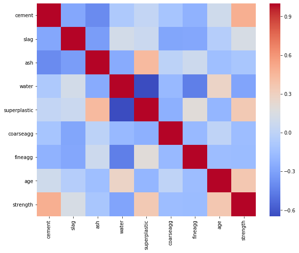

```python
cmat = concrete.corr()
plt.figure(figsize = (10,8))
sns.heatmap(cmat, cmap="coolwarm")
```

### We can find columns with strong correlations to see if there is anything that could be dropped

```python
cmat[cmat > 0.8]
```

|  | cement | slag | ash | water | superplastic | coarseagg | fineagg | age | strength |
| --- | --- | --- | --- | --- | --- | --- | --- | --- | --- |
| cement | 1.0 | NaN | NaN | NaN | NaN | NaN | NaN | NaN | NaN |
| slag | NaN | 1.0 | NaN | NaN | NaN | NaN | NaN | NaN | NaN |
| ash | NaN | NaN | 1.0 | NaN | NaN | NaN | NaN | NaN | NaN |
| water | NaN | NaN | NaN | 1.0 | NaN | NaN | NaN | NaN | NaN |
| superplastic | NaN | NaN | NaN | NaN | 1.0 | NaN | NaN | NaN | NaN |
| coarseagg | NaN | NaN | NaN | NaN | NaN | 1.0 | NaN | NaN | NaN |
| fineagg | NaN | NaN | NaN | NaN | NaN | NaN | 1.0 | NaN | NaN |
| age | NaN | NaN | NaN | NaN | NaN | NaN | NaN | 1.0 | NaN |
| strength | NaN | NaN | NaN | NaN | NaN | NaN | NaN | NaN | 1.0 |

```python
cmat[cmat < -0.8]
```

|  | cement | slag | ash | water | superplastic | coarseagg | fineagg | age | strength |
| --- | --- | --- | --- | --- | --- | --- | --- | --- | --- |
| cement | NaN | NaN | NaN | NaN | NaN | NaN | NaN | NaN | NaN |
| slag | NaN | NaN | NaN | NaN | NaN | NaN | NaN | NaN | NaN |
| ash | NaN | NaN | NaN | NaN | NaN | NaN | NaN | NaN | NaN |
| water | NaN | NaN | NaN | NaN | NaN | NaN | NaN | NaN | NaN |
| superplastic | NaN | NaN | NaN | NaN | NaN | NaN | NaN | NaN | NaN |
| coarseagg | NaN | NaN | NaN | NaN | NaN | NaN | NaN | NaN | NaN |
| fineagg | NaN | NaN | NaN | NaN | NaN | NaN | NaN | NaN | NaN |
| age | NaN | NaN | NaN | NaN | NaN | NaN | NaN | NaN | NaN |
| strength | NaN | NaN | NaN | NaN | NaN | NaN | NaN | NaN | NaN |

### There seem to be no strong correlations among the independent columns

```python
cmat[(cmat<0.2) & (cmat>-0.2)]
```

|  | cement | slag | ash | water | superplastic | coarseagg | fineagg | age | strength |
| --- | --- | --- | --- | --- | --- | --- | --- | --- | --- |
| cement | NaN | NaN | NaN | -0.081118 | 0.027394 | -0.109349 | NaN | 0.087119 | NaN |
| slag | NaN | NaN | NaN | 0.107769 | 0.063680 | NaN | NaN | -0.045875 | 0.137315 |
| ash | NaN | NaN | NaN | NaN | NaN | -0.009961 | 0.079108 | -0.149901 | -0.105755 |
| water | -0.081118 | 0.107769 | NaN | NaN | NaN | -0.179959 | NaN | NaN | NaN |
| superplastic | 0.027394 | 0.063680 | NaN | NaN | NaN | NaN | 0.198164 | -0.198019 | NaN |
| coarseagg | -0.109349 | NaN | -0.009961 | -0.179959 | NaN | NaN | -0.178481 | 0.002719 | -0.164935 |
| fineagg | NaN | NaN | 0.079108 | NaN | 0.198164 | -0.178481 | NaN | -0.161932 | -0.167241 |
| age | 0.087119 | -0.045875 | -0.149901 | NaN | -0.198019 | 0.002719 | -0.161932 | NaN | NaN |
| strength | NaN | 0.137315 | -0.105755 | NaN | NaN | -0.164935 | -0.167241 | NaN | NaN |

```python
cmat
```

|  | cement | slag | ash | water | superplastic | coarseagg | fineagg | age | strength |
| --- | --- | --- | --- | --- | --- | --- | --- | --- | --- |
| cement | 1.000000 | -0.276412 | -0.397467 | -0.081118 | 0.027394 | -0.109349 | -0.222718 | 0.087119 | 0.497832 |
| slag | -0.276412 | 1.000000 | -0.323708 | 0.107769 | 0.063680 | -0.285840 | -0.279427 | -0.045875 | 0.137315 |
| ash | -0.397467 | -0.323708 | 1.000000 | -0.258952 | 0.434550 | -0.009961 | 0.079108 | -0.149901 | -0.105755 |
| water | -0.081118 | 0.107769 | -0.258952 | 1.000000 | -0.647646 | -0.179959 | -0.451000 | 0.276638 | -0.290278 |
| superplastic | 0.027394 | 0.063680 | 0.434550 | -0.647646 | 1.000000 | -0.234995 | 0.198164 | -0.198019 | 0.355451 |
| coarseagg | -0.109349 | -0.285840 | -0.009961 | -0.179959 | -0.234995 | 1.000000 | -0.178481 | 0.002719 | -0.164935 |
| fineagg | -0.222718 | -0.279427 | 0.079108 | -0.451000 | 0.198164 | -0.178481 | 1.000000 | -0.161932 | -0.167241 |
| age | 0.087119 | -0.045875 | -0.149901 | 0.276638 | -0.198019 | 0.002719 | -0.161932 | 1.000000 | 0.365458 |
| strength | 0.497832 | 0.137315 | -0.105755 | -0.290278 | 0.355451 | -0.164935 | -0.167241 | 0.365458 | 1.000000 |

### Ash seems like the variable with the least impact on strength. We can try an iteration by dropping it and comparing results. We can try this after we figure out the polynomial degree

```python
concrete_aggregate_columns = concrete.copy()
```

```python
concrete_aggregate_columns ["aggregates"] = concrete_aggregate_columns["coarseagg"] + concrete_aggregate_columns["fineagg"]
concrete_aggregate_columns ["age_superplastic"] = concrete_aggregate_columns["superplastic"] + concrete_aggregate_columns["age"]
##concrete_aggregate_columns ["cement_age"] = concrete_aggregate_columns["cement"] / concrete_aggregate_columns["age"]
concrete_aggregate_columns = concrete_aggregate_columns.drop(["coarseagg","fineagg","superplastic","age"],axis = 1)
#concrete_aggregate_columns = concrete_aggregate_columns.drop(["coarseagg","fineagg","superplastic","water","age","cement"],axis = 1)
y = concrete_aggregate_columns["strength"]
col_names = concrete_aggregate_columns.drop(["strength"], axis = 1).columns
min_max_scaler = MinMaxScaler()
scaled_concrete_agg = min_max_scaler.fit_transform(concrete_aggregate_columns.drop(["strength"], axis = 1))
scaled_concrete_agg = pd.DataFrame(scaled_concrete_agg, columns = col_names)
y = np.array(y)
y = pd.DataFrame(y, columns = ["strength"])
y = y["strength"]
```

## Q5. Decide on complexity of the model, should it be simple linear model in terms of parameters or would a quadratic or higher degree help

## Ans5

### Now we run 5 polynomial degrees of tests on the input with consolidated features to see what works

```python
x = scaled_concrete_agg
x_train, x_test, y_train, y_test = train_test_split(x, y, test_size = 0.2, random_state = 1)
pipe_lr_poly1 = Pipeline([("Poly",PolynomialFeatures(degree = 1, interaction_only = False)),("regressor", LinearRegression())])
pipe_lr_poly2 = Pipeline([("Poly",PolynomialFeatures(degree = 2, interaction_only = False)),("regressor", LinearRegression())])
pipe_lr_poly3 = Pipeline([("Poly",PolynomialFeatures(degree = 3, interaction_only = False)),("regressor", LinearRegression())])
pipe_lr_poly4 = Pipeline([("Poly",PolynomialFeatures(degree = 4, interaction_only = False)),("regressor", LinearRegression())])
pipe_lr_poly5 = Pipeline([("Poly",PolynomialFeatures(degree = 5, interaction_only = False)),("regressor", LinearRegression())])
pipe_lr_poly1.fit(x_train, y_train)
y_pred1 = pipe_lr_poly1.predict(x_test)
print("1st Degree Train:", pipe_lr_poly1.score(x_train, y_train))
print("1st Degree Test:", pipe_lr_poly1.score(x_test, y_test))
poly1_lr_score_agg = pipe_lr_poly1.score(x_test, y_test)
print(np.percentile(pipe_lr_poly1.named_steps["regressor"].coef_,[0,25,50,75,100]))
print("")
pipe_lr_poly2.fit(x_train, y_train)
y_pred2 = pipe_lr_poly2.predict(x_test)
print("2nd Degree Train:", pipe_lr_poly2.score(x_train, y_train))
print("2nd Degree Test:", pipe_lr_poly2.score(x_test, y_test))
poly2_lr_score_agg = pipe_lr_poly2.score(x_test, y_test)
print(np.percentile(pipe_lr_poly2.named_steps["regressor"].coef_,[0,25,50,75,100]))
print("")
pipe_lr_poly3.fit(x_train, y_train)
y_pred3 = pipe_lr_poly3.predict(x_test)
print("3rd Degree Train:", pipe_lr_poly3.score(x_train, y_train))
print("3rd Degree Test:", pipe_lr_poly3.score(x_test, y_test))
poly3_lr_score_agg = pipe_lr_poly3.score(x_test, y_test)
print(np.percentile(pipe_lr_poly3.named_steps["regressor"].coef_,[0,25,50,75,100]))
print("")
pipe_lr_poly4.fit(x_train, y_train)
y_pred4 = pipe_lr_poly4.predict(x_test)
print("4th Degree Train:", pipe_lr_poly4.score(x_train, y_train))
print("4th Degree Test:", pipe_lr_poly4.score(x_test, y_test))
poly4_lr_score_agg = pipe_lr_poly4.score(x_test, y_test)
print(np.percentile(pipe_lr_poly4.named_steps["regressor"].coef_,[0,25,50,75,100]))
print("")
pipe_lr_poly5.fit(x_train, y_train)
y_pred5 = pipe_lr_poly5.predict(x_test)
print("5th Degree Train:", pipe_lr_poly5.score(x_train, y_train))
print("5th Degree Test:", pipe_lr_poly5.score(x_test, y_test))
poly5_lr_score_agg = pipe_lr_poly5.score(x_test, y_test)
print(np.percentile(pipe_lr_poly5.named_steps["regressor"].coef_,[0,25,50,75,100]))
print("")
```

```
1st Degree Train: 0.6413296003499444
1st Degree Test: 0.669211326927561
[-21.39055449   5.26287992  18.40126359  36.42132181  53.57231013]

2nd Degree Train: 0.7951112864850486
2nd Degree Test: 0.7842828720499742
[-147.78233217  -29.61122626   -4.08038174   23.61713452  227.73397623]

3rd Degree Train: 0.887153050801996
3rd Degree Test: 0.8619891879941961
[-1655.00352321  -299.85640432   -72.97408091   120.51250423
  2703.65830871]

4th Degree Train: 0.9399278900365983
4th Degree Test: 0.856029952407549
[-194016.69240079  -15510.13817331   -3126.66274487    4617.77928764
  155216.44290819]

5th Degree Train: 0.9808596063518794
5th Degree Test: -0.896829884410848
[-1.75470843e+07 -4.60440247e+05  4.32873069e+03  1.29337210e+06
  1.95810703e+07]
```

### It appears as if the 2nd and 3rd degree polynomials works best, further increase in degree has turned counter productive. This can be confirmed by looking at the large coefficients. Let us try ridge and lasso to get a more stable output

```python
pipe_ridge = Pipeline([("Poly",PolynomialFeatures(degree = 2, interaction_only = False)),("regressor", Ridge(alpha = 0.01))])
pipe_ridge.fit(x_train, y_train)
y_pred_ridge = pipe_ridge.predict(x_test)
print("Degree 2, Ridge Train:", pipe_ridge.score(x_train, y_train))
print("Degree 2, Ridge Test:", pipe_ridge.score(x_test, y_test))
ridge_2d_agg = pipe_ridge.score(x_test, y_test)
print(np.percentile(pipe_ridge.named_steps["regressor"].coef_,[0,25,50,75,100]))
print(" ")
pipe_ridge = Pipeline([("Poly",PolynomialFeatures(degree = 3, interaction_only = False)),("regressor", Ridge(alpha = 0.01))])
pipe_ridge.fit(x_train, y_train)
y_pred_ridge = pipe_ridge.predict(x_test)
print("Degree 3, Ridge Train:", pipe_ridge.score(x_train, y_train))
print("Degree 3, Ridge Test:", pipe_ridge.score(x_test, y_test))
ridge_3d_agg = pipe_ridge.score(x_test, y_test)
print(np.percentile(pipe_ridge.named_steps["regressor"].coef_,[0,25,50,75,100]))
print(" ")

#USING VERY SMALL ALPHA
pipe_ridge = Pipeline([("Poly",PolynomialFeatures(degree = 2, interaction_only = False)),("regressor", Ridge(alpha = 0.0001))])
pipe_ridge.fit(x_train, y_train)
y_pred_ridge = pipe_ridge.predict(x_test)
print("Degree 2, Very Small alpha, Ridge Train:", pipe_ridge.score(x_train, y_train))
print("Degree 2, Small alpha, Ridge Test:", pipe_ridge.score(x_test, y_test))
ridge_2d_agg_vsa = pipe_ridge.score(x_test, y_test)
print(np.percentile(pipe_ridge.named_steps["regressor"].coef_,[0,25,50,75,100]))
print(" ")
pipe_ridge = Pipeline([("Poly",PolynomialFeatures(degree = 3, interaction_only = False)),("regressor", Ridge(alpha = 0.0001))])
pipe_ridge.fit(x_train, y_train)
y_pred_ridge = pipe_ridge.predict(x_test)
print("Degree 3, Very Small alpha, Ridge Train:", pipe_ridge.score(x_train, y_train))
print("Degree 3, Very Small alpha, Ridge Test:", pipe_ridge.score(x_test, y_test))
ridge_3d_agg_vsa = pipe_ridge.score(x_test, y_test)
print(np.percentile(pipe_ridge.named_steps["regressor"].coef_,[0,25,50,75,100]))
print(" ")
```

```
Degree 2, Ridge Train: 0.794394484711423
Degree 2, Ridge Test: 0.7823319793834028
[-80.52639989 -11.82974555   8.28280607  33.15592551 107.7760658 ]

Degree 3, Ridge Train: 0.8766165605515388
Degree 3, Ridge Test: 0.8636040175960686
[-232.39225706  -24.01815313    8.3894337    33.13423425  190.42254374]

Degree 2, Very Small alpha, Ridge Train: 0.7951071600143499
Degree 2, Small alpha, Ridge Test: 0.784171177981287
[-140.70292141  -24.82558107   -3.65716421   18.20142829  217.5243345 ]

Degree 3, Very Small alpha, Ridge Train: 0.8865434289039936
Degree 3, Very Small alpha, Ridge Test: 0.8666169774057636
[-431.72859021 -112.92888581    4.17532295   96.70579337  465.3044106 ]
```

### The coefficients still look quite large, we also see that reducing the alpha significantly does not provide us significantly better returns. we will get a better sense when we do a k-fold validation

### We now try Lasso with 2nd and 3rd degree polynomials

```python
pipe_lasso = Pipeline([("Poly",PolynomialFeatures(degree = 2, interaction_only = False)),("regressor", Lasso(alpha = 0.1, max_iter=100000, tol = 0.05, precompute=True, warm_start=True))])
pipe_lasso.fit(x_train, y_train)
y_pred_lasso = pipe_lasso.predict(x_test)
print("Degree 2, Large Alpha, Lasso Train:", pipe_lasso.score(x_train, y_train))
print("Degree 2, Large Alpha, Lasso Test:", pipe_lasso.score(x_test, y_test))
lasso_2d_agg = pipe_lasso.score(x_test, y_test)
print(np.percentile(pipe_lasso.named_steps["regressor"].coef_,[0,25,50,75,100]))
print(" ")
pipe_lasso = Pipeline([("Poly",PolynomialFeatures(degree = 3, interaction_only = False)),("regressor", Lasso(alpha = 0.1, max_iter=100000, tol = 0.05, precompute=True, warm_start=True))])
pipe_lasso.fit(x_train, y_train)
y_pred_lasso = pipe_lasso.predict(x_test)
print("Degree 3, Large Alpha, Lasso Train:", pipe_lasso.score(x_train, y_train))
print("Degree 3, Large Alpha, Lasso Test:", pipe_lasso.score(x_test, y_test))
lasso_3d_agg = pipe_lasso.score(x_test, y_test)
print(np.percentile(pipe_lasso.named_steps["regressor"].coef_,[0,25,50,75,100]))
print(" ")

pipe_lasso = Pipeline([("Poly",PolynomialFeatures(degree = 2, interaction_only = False)),("regressor", Lasso(alpha = 0.0001, max_iter=100000, tol = 0.05, precompute=True, warm_start=True))])
pipe_lasso.fit(x_train, y_train)
y_pred_lasso = pipe_lasso.predict(x_test)
print("Degree 2, Small Alpha, Lasso Train:", pipe_lasso.score(x_train, y_train))
print("Degree 2, Small Alpha, Lasso Test:", pipe_lasso.score(x_test, y_test))
lasso_2d_agg_vsa = pipe_lasso.score(x_test, y_test)
print(np.percentile(pipe_lasso.named_steps["regressor"].coef_,[0,25,50,75,100]))
print(" ")
pipe_lasso = Pipeline([("Poly",PolynomialFeatures(degree = 3, interaction_only = False)),("regressor", Lasso(alpha = 0.0001, max_iter=100000, tol = 0.05, precompute=True, warm_start=True))])
pipe_lasso.fit(x_train, y_train)
y_pred_lasso = pipe_lasso.predict(x_test)
print("Degree 3, Small Alpha, Lasso Train:", pipe_lasso.score(x_train, y_train))
print("Degree 3, Small Alpha, Lasso Test:", pipe_lasso.score(x_test, y_test))
lasso_3d_agg_vsa = pipe_lasso.score(x_test, y_test)
print(np.percentile(pipe_lasso.named_steps["regressor"].coef_,[0,25,50,75,100]))
print(" ")
```

```
Degree 2, Large Alpha, Lasso Train: 0.7062231081153048
Degree 2, Large Alpha, Lasso Test: 0.7168386750278471
[-26.23444529   0.           0.           0.63892108  52.98829497]

Degree 3, Large Alpha, Lasso Train: 0.7185778239424383
Degree 3, Large Alpha, Lasso Test: 0.7288677863732094
[-17.15293784   0.           0.           0.          59.2235827 ]

Degree 2, Small Alpha, Lasso Train: 0.794911432638981
Degree 2, Small Alpha, Lasso Test: 0.7832219958857658
[-99.96784306 -14.39383781   6.72411104  29.81446258 156.92053245]

Degree 3, Small Alpha, Lasso Train: 0.8819263520254639
Degree 3, Small Alpha, Lasso Test: 0.8669210250137146
[-211.64184895  -58.15673593    0.           48.52797654  217.34751609]
```

### We see that using ridge and lasso we can achieve upto 87% accuracy with a 3rd degree polynomial. Thus our choice of degree is 3. We will however, consider degree 2 for decision trees later

## Ans5 Ends. We resume Ans4 to see if we can drop a column in addition to using the principles we engineered

## Ans4 Resumes

### Let us find the results of linear regression against the full set

```python
col_names = concrete.drop(["strength"], axis = 1).columns
min_max_scaler = MinMaxScaler()
scaled_concrete_ = min_max_scaler.fit_transform(concrete.drop(["strength"], axis = 1))
scaled_concrete = pd.DataFrame(scaled_concrete_, columns = col_names)
y = np.array(y)
y = pd.DataFrame(y, columns = ["strength"])
y = y["strength"]
```

```python
x = scaled_concrete
#x_train_test, x_val, y_train_test, y_val = train_test_split(x, y, test_size = 0.2, random_state = 1)
#x_train, x_test, y_train, y_test = train_test_split(x_train_test, y_train_test, test_size = 0.2, random_state = 1)
x_train, x_test, y_train, y_test = train_test_split(x, y, test_size = 0.2, random_state = 1)
pipe_lr_poly2.fit(x_train, y_train)
y_pred_poly2 = pipe_lr_poly2.predict(x_test)
print("Degree 2:", pipe_lr_poly2.score(x_train, y_train))
print("Degree 2:", pipe_lr_poly2.score(x_test, y_test))
print(np.percentile(pipe_lr_poly2.named_steps["regressor"].coef_,[0,25,50,75,100]))
lr_2d_full = pipe_lr_poly2.score(x_test, y_test)
print(" ")

pipe_lr_poly3.fit(x_train, y_train)
y_pred_poly3 = pipe_lr_poly3.predict(x_test)
print("Degree 3:", pipe_lr_poly3.score(x_train, y_train))
print("Degree 3:", pipe_lr_poly3.score(x_test, y_test))
lr_3d_full = pipe_lr_poly3.score(x_test, y_test)
print(np.percentile(pipe_lr_poly3.named_steps["regressor"].coef_,[0,25,50,75,100]))
```

```
Degree 2: 0.8216196226525259
Degree 2: 0.8194688368997106
[-202.38690726  -75.40195503  -26.70718154   15.31848824  415.57382785]

Degree 3: 0.9334290998406095
Degree 3: 0.8942395977345124
[-4702.96104669  -677.81099996  -163.11397616   238.34308901
  5642.53155548]
```

### Let us now do a regression after Dropping ash

```python
concrete_without_ash = scaled_concrete.drop("ash", axis = 1)
```

```python
x = concrete_without_ash
#x_train_test, x_val, y_train_test, y_val = train_test_split(x, y, test_size = 0.2, random_state = 1)
#x_train, x_test, y_train, y_test = train_test_split(x_train_test, y_train_test, test_size = 0.2, random_state = 1)
x_train, x_test, y_train, y_test = train_test_split(x, y, test_size = 0.2, random_state = 1)
pipe_lr_poly2.fit(x_train, y_train)
y_pred_no_ash_poly2 = pipe_lr_poly2.predict(x_test)
print(pipe_lr_poly2.score(x_train, y_train))
print(pipe_lr_poly2.score(x_test, y_test))
lr_2d_noash = pipe_lr_poly2.score(x_test, y_test)
print(np.percentile(pipe_lr_poly2.named_steps["regressor"].coef_,[0,25,50,75,100]))
print(" ")
pipe_lr_poly3.fit(x_train, y_train)
y_pred_no_ash_poly3 = pipe_lr_poly3.predict(x_test)
print(pipe_lr_poly3.score(x_train, y_train))
print(pipe_lr_poly3.score(x_test, y_test))
lr_3d_noash = pipe_lr_poly3.score(x_test, y_test)
print(np.percentile(pipe_lr_poly3.named_steps["regressor"].coef_,[0,25,50,75,100]))
```

```
0.8085396711223661
0.8103739293106089
[-110.33290062  -34.93507548  -13.52250097   14.24703181  153.697954  ]

0.9143795778338382
0.8863578050949454
[-853.29054317 -176.12327431   38.055192    181.66643807  886.27746505]
```

### Dropping ash has had a 1% impact on the outcome. However, the coefficients of the third degree equation still look too large to be useable and are possibly overfit. We will try ridge and lasso to see if we can smooth this.

### We try a Ridge regression on the third degree equation

```python
pipe_ridge = Pipeline([("Poly",PolynomialFeatures(degree = 3, interaction_only = False)),("regressor", Ridge(alpha = 0.3))])
pipe_ridge.fit(x_train, y_train)
y_pred_ridge = pipe_ridge.predict(x_test)
print("Ridge, Degree 3, alpha 0.3, Train:", pipe_ridge.score(x_train, y_train))
print("Ridge, Degree 3, alpha 0.3, Test:", pipe_ridge.score(x_test, y_test))
print(np.percentile(pipe_ridge.named_steps["regressor"].coef_,[0,25,50,75,100]))
print(" ")
pipe_ridge = Pipeline([("Poly",PolynomialFeatures(degree = 3, interaction_only = False)),("regressor", Ridge(alpha = 0.1))])
pipe_ridge.fit(x_train, y_train)
y_pred_ridge = pipe_ridge.predict(x_test)
print("Ridge, Degree 3, alpha 0.1, Train:", pipe_ridge.score(x_train, y_train))
print("Ridge, Degree 3, alpha 0.1, Test:", pipe_ridge.score(x_test, y_test))
print(np.percentile(pipe_ridge.named_steps["regressor"].coef_,[0,25,50,75,100]))
ridge_best_noash = pipe_ridge.score(x_test, y_test)
print(" ")
pipe_ridge = Pipeline([("Poly",PolynomialFeatures(degree = 3, interaction_only = False)),("regressor", Ridge(alpha = 0.07))])
pipe_ridge.fit(x_train, y_train)
y_pred_ridge = pipe_ridge.predict(x_test)
print("Ridge, Degree 3, alpha 0.07, Train:", pipe_ridge.score(x_train, y_train))
print("Ridge, Degree 3, alpha 0.07, Test:", pipe_ridge.score(x_test, y_test))
print(np.percentile(pipe_ridge.named_steps["regressor"].coef_,[0,25,50,75,100]))
print(" ")
pipe_ridge = Pipeline([("Poly",PolynomialFeatures(degree = 3, interaction_only = False)),("regressor", Ridge(alpha = 0.05))])
pipe_ridge.fit(x_train, y_train)
y_pred_ridge = pipe_ridge.predict(x_test)
print("Ridge, Degree 3, alpha 0.05, Train:", pipe_ridge.score(x_train, y_train))
print("Ridge, Degree 3, alpha 0.05, Test:", pipe_ridge.score(x_test, y_test))
print(np.percentile(pipe_ridge.named_steps["regressor"].coef_,[0,25,50,75,100]))
```

```
Ridge, Degree 3, alpha 0.3, Train: 0.8306126418491222
Ridge, Degree 3, alpha 0.3, Test: 0.8211759952328107
[-47.79709215  -5.21209271   2.66095338   9.16419162  54.00301336]

Ridge, Degree 3, alpha 0.1, Train: 0.8608356169395147
Ridge, Degree 3, alpha 0.1, Test: 0.8477936415008565
[-92.277909    -8.75856919   1.88504899  13.24410609  75.74449834]

Ridge, Degree 3, alpha 0.07, Train: 0.8699143176858308
Ridge, Degree 3, alpha 0.07, Test: 0.8562080717032907
[-110.86925549  -11.02413051    0.91858311   15.77290383   96.98312769]

Ridge, Degree 3, alpha 0.05, Train: 0.8776206891794192
Ridge, Degree 3, alpha 0.05, Test: 0.8633124871125887
[-129.35184673  -12.1950965     0.89201488   17.89478855  116.84571213]
```

### We see alpha = 0.05 as the value that keeps accuracy at a reasonable level for the 3rd degree polynomial and does not allow the coefficients to get too high

### We try a Lasso regression on the third degree equation

```python
pipe_lasso = Pipeline([("Poly",PolynomialFeatures(degree = 3, interaction_only = False)),("regressor", Lasso(alpha = 1, max_iter=100000, tol = 0.0001, precompute=True, warm_start=True))])
pipe_lasso.fit(x_train, y_train)
y_pred_lasso = pipe_lasso.predict(x_test)
print("Lasso, Degree 3, alpha 0.1, Train:", pipe_lasso.score(x_train, y_train))
print("Lasso, Degree 3, alpha 0.1, Test:", pipe_lasso.score(x_test, y_test))
print(np.percentile(pipe_ridge.named_steps["regressor"].coef_,[0,25,50,75,100]))
print(" ")
pipe_lasso = Pipeline([("Poly",PolynomialFeatures(degree = 3, interaction_only = False)),("regressor", Lasso(alpha = 0.1, max_iter=100000, tol = 0.0001, precompute=True, warm_start=True))])
pipe_lasso.fit(x_train, y_train)
y_pred_lasso = pipe_lasso.predict(x_test)
print("Lasso, Degree 3, alpha 0.05, Train:", pipe_lasso.score(x_train, y_train))
print("Lasso, Degree 3, alpha 0.05, Test:", pipe_lasso.score(x_test, y_test))
print(np.percentile(pipe_ridge.named_steps["regressor"].coef_,[0,25,50,75,100]))
print(" ")
pipe_lasso = Pipeline([("Poly",PolynomialFeatures(degree = 3, interaction_only = False)),("regressor", Lasso(alpha = 0.01, max_iter=100000, tol = 0.0001, precompute=True, warm_start=True))])
pipe_lasso.fit(x_train, y_train)
y_pred_lasso = pipe_lasso.predict(x_test)
print("Lasso, Degree 3, alpha 0.01, Train:", pipe_lasso.score(x_train, y_train))
print("Lasso, Degree 3, alpha 0.01, Test:", pipe_lasso.score(x_test, y_test))
print(np.percentile(pipe_ridge.named_steps["regressor"].coef_,[0,25,50,75,100]))
print(" ")
pipe_lasso = Pipeline([("Poly",PolynomialFeatures(degree = 3, interaction_only = False)),("regressor", Lasso(alpha = 0.001, max_iter=100000, tol = 0.0001, precompute=True, warm_start=True))])
pipe_lasso.fit(x_train, y_train)
y_pred_lasso = pipe_lasso.predict(x_test)
print("Lasso, Degree 3, alpha 0.005, Train:", pipe_lasso.score(x_train, y_train))
print("Lasso, Degree 3, alpha 0.005, Test:", pipe_lasso.score(x_test, y_test))
print(np.percentile(pipe_ridge.named_steps["regressor"].coef_,[0,25,50,75,100]))
lasso_best_noash = pipe_lasso.score(x_test, y_test)
print(" ")
pipe_lasso = Pipeline([("Poly",PolynomialFeatures(degree = 3, interaction_only = False)),("regressor", Lasso(alpha = 0.0001, max_iter=1000000, tol = 0.00001, precompute=True, warm_start=True))])
pipe_lasso.fit(x_train, y_train)
y_pred_lasso = pipe_lasso.predict(x_test)
print("Lasso, Degree 3, alpha 0.0001, Train:", pipe_lasso.score(x_train, y_train))
print("Lasso, Degree 3, alpha 0.0001, Test:", pipe_lasso.score(x_test, y_test))
print(np.percentile(pipe_ridge.named_steps["regressor"].coef_,[0,25,50,75,100]))
print(" ")
```

```
Lasso, Degree 3, alpha 0.1, Train: 0.2813554259203037
Lasso, Degree 3, alpha 0.1, Test: 0.2605595792690587
[-129.35184673  -12.1950965     0.89201488   17.89478855  116.84571213]

Lasso, Degree 3, alpha 0.05, Train: 0.718997721235981
Lasso, Degree 3, alpha 0.05, Test: 0.7296107358197804
[-129.35184673  -12.1950965     0.89201488   17.89478855  116.84571213]

Lasso, Degree 3, alpha 0.01, Train: 0.8353598911158324
Lasso, Degree 3, alpha 0.01, Test: 0.8362785302957619
[-129.35184673  -12.1950965     0.89201488   17.89478855  116.84571213]

Lasso, Degree 3, alpha 0.005, Train: 0.898102471589751
Lasso, Degree 3, alpha 0.005, Test: 0.8874010853208075
[-129.35184673  -12.1950965     0.89201488   17.89478855  116.84571213]

Lasso, Degree 3, alpha 0.0001, Train: 0.9118945948702268
Lasso, Degree 3, alpha 0.0001, Test: 0.8832536836224822
[-129.35184673  -12.1950965     0.89201488   17.89478855  116.84571213]
```

## Ans4 Ends here,

## Ans5 was already covered above.. We now cover Q6

## Q6. Explore for gaussians. If data is likely to be a mix of gaussians, explore individual clusters and present your findings in terms of the independent attributes and their suitability to predict strength

## Ans6

### Let us try a KMeans to create possible Gaussian clusters

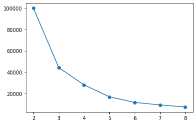

```python
final_concrete = pd.concat([scaled_concrete, y], axis = 1)
c_range = range(2,9)
cluster_err = []
for i in c_range:
    km = KMeans(i, n_init=5)
    km.fit(final_concrete)
    labels = km.labels_
    centroids = km.cluster_centers_
    cluster_err.append(km.inertia_)
cluster_df = pd.DataFrame({"num_clusters":c_range, "cluster_errors":cluster_err})
plt.plot(cluster_df["num_clusters"],cluster_df["cluster_errors"], marker = "o")
```

```python
km = KMeans (5, n_init = 5)
km.fit(final_concrete)
labels = km.labels_
centroids = km.cluster_centers_
label_col = pd.DataFrame(labels, columns = ["labels"])
final_concrete_labeled = pd.concat([final_concrete,label_col], axis =1)
final_concrete_arr = []

#create an array of the individual sub clusters
final_concrete_arr.append(final_concrete_labeled[final_concrete_labeled["labels"] == 0])
final_concrete_arr.append(final_concrete_labeled[final_concrete_labeled["labels"] == 1])
final_concrete_arr.append(final_concrete_labeled[final_concrete_labeled["labels"] == 2])
final_concrete_arr.append(final_concrete_labeled[final_concrete_labeled["labels"] == 3])
final_concrete_arr.append(final_concrete_labeled[final_concrete_labeled["labels"] == 4])

#iterate through the array and predict
for i in range(0,5):
    y = final_concrete_arr[i]["strength"]
    x = final_concrete_arr[i].drop("strength", axis = 1)
    x_train, x_test, y_train, y_test = train_test_split(x, y, test_size = 0.2, random_state = 1)
    pipe_lr_poly1.fit(x_train, y_train)
    y_pred_poly1 = pipe_lr_poly1.predict(x_test)
    print("Degree 1, Set", i, "Train", pipe_lr_poly1.score(x_train, y_train))
    print("Degree 1, Set", i, "Test",pipe_lr_poly1.score(x_test, y_test))
    pipe_lr_poly2.fit(x_train, y_train)
    y_pred_poly2 = pipe_lr_poly2.predict(x_test)
    print("Degree 2, Set", i, "Train", pipe_lr_poly2.score(x_train, y_train))
    print("Degree 2, Set", i, "Test",pipe_lr_poly2.score(x_test, y_test))
    pipe_lr_poly3.fit(x_train, y_train)
    y_pred_poly3 = pipe_lr_poly3.predict(x_test)
    print("Degree 3, Set", i, "Train", pipe_lr_poly3.score(x_train, y_train))
    print("Degree 3, Set", i, "Test",pipe_lr_poly3.score(x_test, y_test))
    pipe_lr_poly4.fit(x_train, y_train)
    y_pred_poly4 = pipe_lr_poly4.predict(x_test)
    print("Degree 4, Set", i, "Train", pipe_lr_poly4.score(x_train, y_train))
    print("Degree 4, Set", i, "Test",pipe_lr_poly4.score(x_test, y_test))
    print(" ")
```

```
Degree 1, Set 0 Train 0.03404217317427105
Degree 1, Set 0 Test 0.05055790310458419
Degree 2, Set 0 Train 0.41798890319223
Degree 2, Set 0 Test 0.03541396507425432
Degree 3, Set 0 Train -4.002863569302157
Degree 3, Set 0 Test -47.53186468842309
Degree 4, Set 0 Train 0.9969831409169382
Degree 4, Set 0 Test -1145692138003846.0

Degree 1, Set 1 Train 0.4467531994187749
Degree 1, Set 1 Test 0.5332132483170979
Degree 2, Set 1 Train 0.3400837339291055
Degree 2, Set 1 Test 0.483402189190114
Degree 3, Set 1 Train 0.9938871771968488
Degree 3, Set 1 Test -7670.601828605715
Degree 4, Set 1 Train 1.0
Degree 4, Set 1 Test -1048.9831998190066

Degree 1, Set 2 Train 0.2411365684930068
Degree 1, Set 2 Test 0.1040921165664459
Degree 2, Set 2 Train 0.9837787307657165
Degree 2, Set 2 Test -622.4779318217774
Degree 3, Set 2 Train 0.9989814451121342
Degree 3, Set 2 Test -1.3325034004854494e+21
Degree 4, Set 2 Train 0.9989841198996031
Degree 4, Set 2 Test -1.3396259755362134e+20

Degree 1, Set 3 Train 0.13382932820976667
Degree 1, Set 3 Test 0.10439043502821455
Degree 2, Set 3 Train 0.4982579925048992
Degree 2, Set 3 Test -0.008814403090479095
Degree 3, Set 3 Train 0.9433743564069791
Degree 3, Set 3 Test -7.540160093037571
Degree 4, Set 3 Train 0.9996299077053238
Degree 4, Set 3 Test -808299835.9979241

Degree 1, Set 4 Train 0.373851325622495
Degree 1, Set 4 Test -0.13306234425055807
Degree 2, Set 4 Train 0.6493302212454386
Degree 2, Set 4 Test -0.8567427068816822
Degree 3, Set 4 Train 0.9790237568991451
Degree 3, Set 4 Test -1485.280331784629
Degree 4, Set 4 Train 0.980797283261612
Degree 4, Set 4 Test -326.40607404781156
```

#### Our attempt to seperate out the Gaussians has not worked. Across all 4 polynomial degrees, the outcome is not in acceptable ranges. It seems the dataset is far too interlinked to separate it into clusters. Also we have achieved almost 90% accuracy without Gaussian seperation and there seems to be no need to do further bifurcation. Consequently, we will not pursue this further

## Q7. Obtain feature importance for the individual features and present your findings

## Ans7

### We now attempt to find the feature importance and present it

```
0.7252529758724646
0.7104292378741579
```

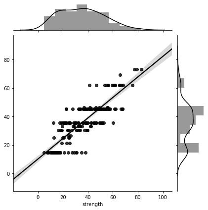

```python
dtr = DecisionTreeRegressor(max_depth = 4)
x = final_concrete.drop("strength",axis = 1)
y = final_concrete["strength"]
x_train, x_test, y_train, y_test = train_test_split(x, y, test_size = 0.2, random_state = 1)
dtr.fit(x_train, y_train)
print(dtr.score(x_train, y_train))
print(dtr.score(x_test, y_test))
y_pred = dtr.predict(x_test)
sns.jointplot(x = y_test, y = y_pred, kind = "reg", color = "k")
```

### In our first degree dataset, we see only an accuracy of 71% on the test set

```python
feature_imp = pd.DataFrame ([x.columns,dtr.feature_importances_ ])
feature_imp = feature_imp.transpose()
feature_imp.columns = ["Element","Importance"]
feature_imp.sort_values(by = "Importance", ascending= False)
```

|  | Element | Importance |
| --- | --- | --- |
| 0 | cement | 0.433849 |
| 7 | age | 0.371959 |
| 1 | slag | 0.099784 |
| 3 | water | 0.0717946 |
| 6 | fineagg | 0.0188312 |
| 4 | superplastic | 0.00378148 |
| 2 | ash | 0 |
| 5 | coarseagg | 0 |

### When we keep the equation in first degree, it seems that ash and coarseagg columns have no importance at all. Infact, even superplastic seems to have very low contribution (<1%)

```
0.7714176360364384
0.7710779470773759
```

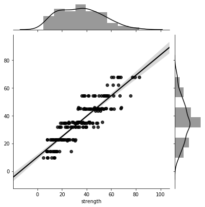

```python
dtr = DecisionTreeRegressor(max_depth = 4)
poly = PolynomialFeatures(degree = 2, interaction_only = False)
x_poly = poly.fit_transform(x)
x_train, x_test, y_train, y_test = train_test_split(x_poly, y, test_size = 0.2, random_state = 1)
dtr.fit(x_train, y_train)
print(dtr.score(x_train, y_train))
print(dtr.score(x_test, y_test))
dtr_2d_noash = dtr.score(x_test, y_test)
y_pred = dtr.predict(x_test)
sns.jointplot(x = y_test, y = y_pred, kind = "reg", color = "k")
```

### Converting to a 2nd degree polynomial, improves the decision tree prediction to 77%

```python
feature_imp = pd.DataFrame ([dtr.feature_importances_ ])
feature_imp = feature_imp.transpose()
feature_imp.columns = ["Importance"]
feature_imp.sort_values(by = "Importance", ascending= False).iloc[:15,:]
```

|  | Importance |
| --- | --- |
| 16 | 0.661206 |
| 33 | 0.128440 |
| 20 | 0.056687 |
| 13 | 0.055334 |
| 23 | 0.045843 |
| 10 | 0.027609 |
| 4 | 0.011530 |
| 31 | 0.010998 |
| 41 | 0.002354 |
| 0 | 0.000000 |
| 28 | 0.000000 |
| 29 | 0.000000 |
| 30 | 0.000000 |
| 32 | 0.000000 |
| 35 | 0.000000 |

```
0.7931732687588426
0.7881914144518359
```

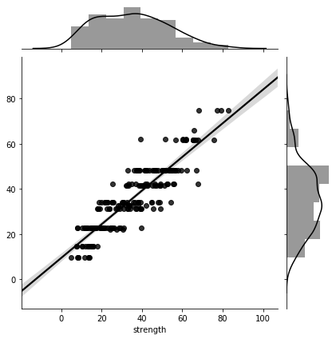

```python
dtr = DecisionTreeRegressor(max_depth = 4)
poly = PolynomialFeatures(degree = 3, interaction_only = False)
x_poly = poly.fit_transform(x)
x_train, x_test, y_train, y_test = train_test_split(x_poly, y, test_size = 0.2, random_state = 1)
dtr.fit(x_train, y_train)
print(dtr.score(x_train, y_train))
print(dtr.score(x_test, y_test))
dtr_3d_noash = dtr.score(x_test, y_test)
y_pred = dtr.predict(x_test)
sns.jointplot(x = y_test, y = y_pred, kind = "reg", color = "k")
```

### Converting to a 3rd degree polynomial, improves the decision tree prediction to almost 79%, The question here is if this output is stable. It appears lower than the ridge and lasso outcomes. However, we will check it in KFold Validation

```python
feature_imp = pd.DataFrame ([x.columns,dtr.feature_importances_ ])
feature_imp = feature_imp.transpose()
feature_imp.columns = ["Element","Importance"]
feature_imp.sort_values(by = "Importance", ascending= False).iloc[:15,:]
```

|  | Element | Importance |
| --- | --- | --- |
| 80 | NaN | 0.541493 |
| 56 | NaN | 0.134728 |
| 33 | NaN | 0.0845061 |
| 16 | NaN | 0.0843624 |
| 13 | NaN | 0.0506808 |
| 75 | NaN | 0.027332 |
| 107 | NaN | 0.0226865 |
| 71 | NaN | 0.0203498 |
| 46 | NaN | 0.012488 |
| 52 | NaN | 0.00923746 |
| 124 | NaN | 0.00693261 |
| 157 | NaN | 0.00263517 |
| 31 | NaN | 0.00219398 |
| 17 | NaN | 0.000374075 |
| 114 | NaN | 0 |

## Q8. Algorithms that you think will be suitable for this project

## Ans8

### We can try a range of algorithms on the data to see what works. However, since the problem involves continuous variables, we must use regressors.

## Base set. We are using the Full data here

### Linear Regression 3rd Degree polynomial

```
0.9334290998406095
0.8942395977345124
[-4702.96104669  -677.81099996  -163.11397616   238.34308901
  5642.53155548]
```

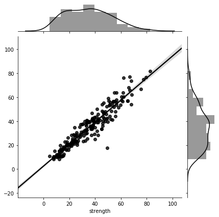

```python
x = scaled_concrete
x_train, x_test, y_train, y_test = train_test_split(x, y, test_size = 0.2, random_state = 1)
pipe_lr_poly3.fit(x_train, y_train)
y_pred_poly3 = pipe_lr_poly3.predict(x_test)
print(pipe_lr_poly3.score(x_train, y_train))
print(pipe_lr_poly3.score(x_test, y_test))
lr_3d_full = pipe_lr_poly3.score(x_test, y_test)
print(np.percentile(pipe_lr_poly3.named_steps["regressor"].coef_,[0,25,50,75,100]))
sns.jointplot(x = y_test, y = y_pred_poly3, kind = "reg", color = "k")
```

### Linear regression works very well with a third degree polynomial. However, a word of caution, as the coefficients are ridiculously high. This may not perform well on a test set with KFold validation

### Decision Tree Regressor 2nd Degree Polynomial

```
0.7714176360364384
0.7710779470773759
```

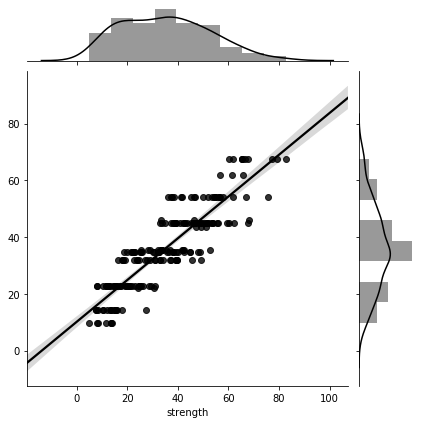

```python
x = scaled_concrete
poly = PolynomialFeatures(degree = 2, interaction_only = False)
x_poly = poly.fit_transform(x)
x_train, x_test, y_train, y_test = train_test_split(x_poly, y, test_size = 0.2, random_state = 1)
dtr = DecisionTreeRegressor(max_depth = 4)
dtr.fit(x_train, y_train)
y_pred_dtr = dtr.predict(x_test)
print(dtr.score(x_train, y_train))
print(dtr.score(x_test, y_test))
dtr_2d = dtr.score(x_test, y_test)
sns.jointplot(x = y_test, y = y_pred_dtr, kind = "reg", color = "k")
```

### Decision Tree Regressor 3rd Degree Polynomial

```
0.7931732687588426
0.7880783384118708
```

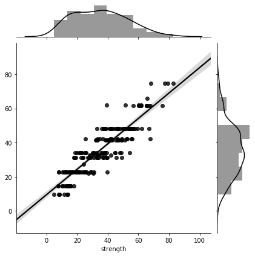

```python
x = scaled_concrete
poly = PolynomialFeatures(degree = 3, interaction_only = False)
x_poly = poly.fit_transform(x)
x_train, x_test, y_train, y_test = train_test_split(x_poly, y, test_size = 0.2, random_state = 1)
dtr = DecisionTreeRegressor(max_depth = 4)
dtr.fit(x_train, y_train)
y_pred_dtr = dtr.predict(x_test)
print(dtr.score(x_train, y_train))
print(dtr.score(x_test, y_test))
dtr_3d = dtr.score(x_test, y_test)
sns.jointplot(x = y_test, y = y_pred_dtr, kind = "reg", color = "k")
```

### Decision trees performance continue to hover around the 78-79% mark. This could be a sign of a stable output. We can test this in KFold Validation

### Support Vector Regressor

```
0.8824379221149105
0.8422640824327309
```

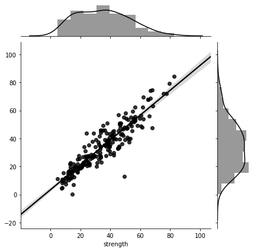

```python
svr = SVR(kernel="poly", degree = 4, C = 2)
x_train, x_test, y_train, y_test = train_test_split(x, y, test_size = 0.2, random_state = 1)
svr.fit(x_train, y_train)
print(svr.score(x_train, y_train))
print(svr.score(x_test, y_test))
svr_4d = svr.score(x_test, y_test)
y_pred = svr.predict(x_test)
sns.jointplot(x = y_test, y = y_pred, kind = "reg", color = "k")
```

### The SVR performance is around 84%. This seems to be lower than the linear models, but is it more stable in a KFold?